# 03-starting-with-data-gapminder

### We want to:

- load that data into memory,
- calculate the total population per year across all countries, and
- plot the result. To do that, we'll have to learn a little bit about programming.

### Objectives

- Read tabular data from a file into a program.
- Assign values to variables.
- Learn about data types
- Select individual values and subsections from data.
- Perform operations on arrays of data.
- Display simple graphs.

## Loading Data

To load our data, we need to locate our data. We will use `setwd()` and `read.csv()`. These are built-in functions in R. Let's check out the help screen.

### Analyzing Gap Minder Data

We will use the same data as we used in the Linux shell tutorial, derived from http://www.gapminder.org

```r
setwd("novice/r/")
```

```
## Error: cannot change working directory
```

```r
gapmindDataURL <- "http://www.stat.ubc.ca/~jenny/notOcto/STAT545A/examples/gapminder/data/gapminderDataFiveYear.txt"
read.delim(file = gapmindDataURL)
```

[output not shown]

The expression `read.delim()` is a function call that asks R to run the function read.delim that belongs to base R.

`read.delim` has many parameters including the name of the file we want to read, and the delimiter that separates values on a line. These both need to be character strings (or strings for short), so we put them in quotes. `header` tells the program if the first line contains column names or data.

When we are finished typing and press `Control+Enter` on Windows or `Cmd + Return` on Mac, the console runs our command. Since we haven't told it to do anything else with the function's output, the console displays it. In this case, that output is the data we just loaded.

```r
dat <- read.delim(file = gapmindDataURL)
data <- dat  #hack
```

This statement doesn't produce any output because assignment doesn't display anything. If we want to check that our data has been loaded, we can print the variable's value:

```r
head(dat)
```

[output not shown]

**BREAK**

- Make sure everyone has imported the data
- tell me how many rows and columns there are
- what kind of data is it?

## Manipulating Data

Now that our data is in memory, we can start doing things with it. First, let's ask what type of thing data refers to:

```r
class(dat)
str(dat)
summary(dat)
```

We can see what its shape is like this:

```r
dim(dat)
nrow(dat)
ncol(dat)
```

### Indexing and subsetting data

If we want to get a single value from the data frame, we must provide an index of row,column in square brackets:

```r
paste("first value in data:", dat[1, 1])
```

An index like [1, 1] selects a single element of an array, but we can select whole sections as well. For example, we can select the values for the first four (rows) like this:

```r
dat[1:4, ]
```

The slice 1:4 means, “Start at index 1 and go to index 4.”

We can also take a set of arbitrary rows. Here, we use the built-in function seq to take regularly spaced rows.

```r
dat[seq(1, 12, 3), ]
```

Seq includes the lower bound, and stops when the upper bound is reached or crossed.

We can also select a subset of columns

```r
# by position (from left to right)
dat[1:5, 1]

# by name
dat[1:5, c("year", "lifeExp")]
```

There are lots of useful built-in commands that we can use in R:

```r
paste("maximum population size:", max(dat[, "pop"]))
paste("minimum population size:", min(dat[, "pop"]))
paste("standard deviation:", sd(dat[, "pop"]))
```

When analyzing data, though, we often want to look at partial statistics, such as the maximum value per patient or the average value per day. One way to do this is to select the data we want to create a new temporary array, then ask it to do the calculation:

```r
population <- dat[, "pop"]  # values in the column 'pop', all rows
paste("maximum value for population size:", max(population))
```

We don't actually need to store the column in a variable of its own. Instead, we can combine the selection and the method call:

```r
max(dat[, "pop"])
```

**EXERCISE**

1. If data holds our array of gapminder data, what does `data[3:3, 4:4]` produce? What about `data[4:1,]`? Explain the results to the person sitting next to you

There another way to get named columns, using the dollar sign

```r
head(data$country)
```

We can also subset data based on the values meeting given criteria. Remember 'grep' from the linux exercise? Here we use the operator == to check if values are identical

```r
data[data$country == "Norway", ]
data[data$country == "Norway" & data$year > 1990, ]

data[with(data, country == "Norway" & year > 1990), ]
```

What's going on there? Each comparison (==, >) generates a logical vector! TRUE, FALSE.. one value for each row. TRUE means the values on that row satisfies the criteria given. Then those are used as indexes to select the corresponding rows from data.

```r
data$year > 1990
```

## Using FUNCTIONS to perform operations across groups

### Analysis over groups: split, tapply

Suppose we need to calculate the mean population size for each country, across all years? We could start by splitting the population vector into a list of population vectors divided by country.

`split` is a useful function for breaking up a vector into groups defined by a second vector, typically a factor. We can then use the `lapply` function to calculate the average of each element of the list, which are vectors of pop sizes.

```r
sp <- split(data$pop, data$country)
sp
lapply(sp, mean)
```

lapply is an example of a functional call, where we send a function to be applied across a dataset.

A shortcut for this is to use `tapply` and give the function which should run on each element of the list as a third argument:

```r
tapply(data$pop, data$country, mean)
```

### Challenge

1. Use tapply to find the maximum and minimum values for population each year.
2. Save these values to two varibles (one for min, one for max).
3. What kind of variables are these?

#plot data

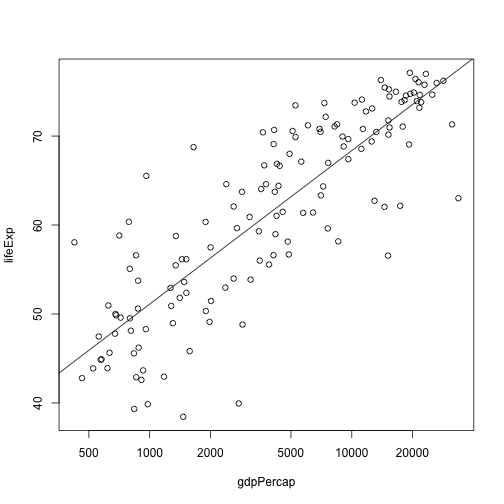

```r
# the gapminder data is quite large, let's subset the data to only hold
# information from 1982
data.1982 = data[data$year == 1982, ]

# now
plot(lifeExp ~ gdpPercap, data.1982, log = "x")
fit = lm(lifeExp ~ log10(gdpPercap), data.1982)
abline(fit)
```

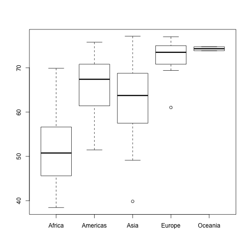

```r
summary(fit)

boxplot(lifeExp ~ continent, data.1982)
```

[output not shown]

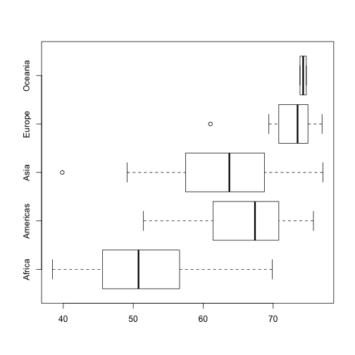

```r
boxplot(lifeExp ~ continent, data.1982, horizontal = TRUE)
```

### Exercise

plot(gdpPercap ~ year, data[data$continent==“Europe”,])

Plot the gdp per capita (gdpPerCap) as a function of time, for european countries

#stats?

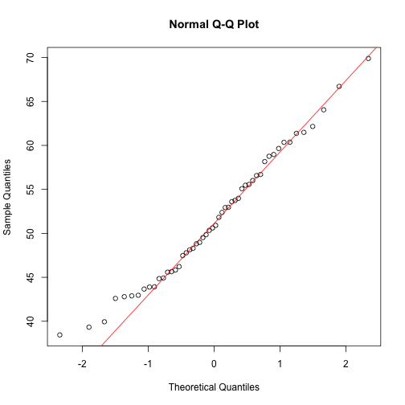

```r
lifeExp_africa <- data.1982[data.1982$continent == "Africa", "lifeExp"]
lifeExp_americas <- data.1982[data.1982$continent == "Americas", "lifeExp"]

# is this normally distributed?
qqnorm(lifeExp_africa)
qqline(lifeExp_africa, col = 2)
```

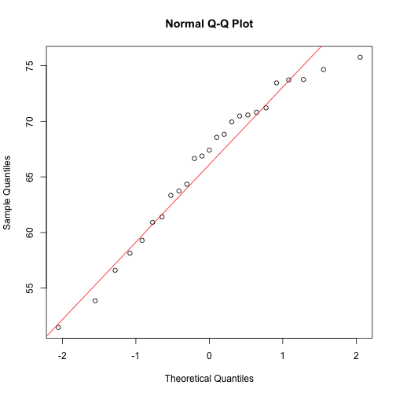

```r
qqnorm(lifeExp_americas)
qqline(lifeExp_americas, col = 2)
```

```r
t.test(lifeExp_africa, lifeExp_americas)
wilcox.test(lifeExp_africa, lifeExp_americas)  #robust comparison
```

[output not shown]